# Data Summarization Lab Key

# Data used

Bike Lanes Dataset: BikeBaltimore is the Department of Transportation’s bike program. The data is from http://data.baltimorecity.gov/Transportation/Bike-Lanes/xzfj-gyms

You can Download as a CSV in your current working directory. Note its also available at: http://jhudatascience.org/intro_to_R_class/data/Bike_Lanes.csv

```r
library(readr)
library(dplyr)
library(tidyverse)
library(jhur)

bike = read_csv(
  "http://jhudatascience.org/intro_to_R_class/data/Bike_Lanes.csv")
```

or use

```r
library(jhur)
bike <- read_bike()
```

# Part 1

1. How many bike “lanes” are currently in Baltimore? You can assume each observation/row is a different bike “lane”. (hint: how do you get the number of rows of a data set? You can use `dim()` or `nrow()` or another function).

```r
nrow(bike)
```

```
## [1] 1631
```

```r
dim(bike)
```

```
## [1] 1631    9
```

```r
bike %>%
  nrow()
```

```
## [1] 1631
```

2. How many feet of bike “lanes” are currently in Baltimore, based on the `length` column? (use `sum()`)

```r
sum(bike$length)
```

```
## [1] 439447.6
```

```r
sum(bike %>% pull(length))
```

```
## [1] 439447.6
```

3. Summarize the data to get the `max` and `min` of `length` using the `summarize` function.

```r
bike %>% summarize(max = max(length),
                   min = min(length))
```

```
## # A tibble: 1 x 2
##     max   min
##   <dbl> <dbl>
## 1 3749.     0
```

# Part 2

4. How many types of bike lanes are there? (Hints: `unique`, `table`, or `bike %>% count()` on the column named `type`).

```r
# So many ways!!

bike %>% count(type)
```

```
## # A tibble: 8 x 2
##   type                n
##   <chr>           <int>
## 1 BIKE BOULEVARD     49
## 2 BIKE LANE         621
## 3 CONTRAFLOW         13
## 4 SHARED BUS BIKE    39
## 5 SHARROW           589
## 6 SIDEPATH            7
## 7 SIGNED ROUTE      304
## 8 <NA>                9
```

```r
bike %>% pull(type) %>% table()
```

```
## .
##  BIKE BOULEVARD       BIKE LANE      CONTRAFLOW SHARED BUS BIKE         SHARROW
##              49             621              13              39             589
##        SIDEPATH    SIGNED ROUTE
##               7             304
```

```r
unique(bike %>% pull(type))
```

```
## [1] "BIKE BOULEVARD"  "SIDEPATH"        "SIGNED ROUTE"    "BIKE LANE"
## [5] "SHARROW"         NA                "CONTRAFLOW"      "SHARED BUS BIKE"
```

```r
table(bike$type, useNA = "ifany")
```

```
##
##  BIKE BOULEVARD       BIKE LANE      CONTRAFLOW SHARED BUS BIKE         SHARROW
##              49             621              13              39             589
##        SIDEPATH    SIGNED ROUTE            <NA>
##               7             304               9
```

```r
unique(bike$type)
```

```
## [1] "BIKE BOULEVARD"  "SIDEPATH"        "SIGNED ROUTE"    "BIKE LANE"
## [5] "SHARROW"         NA                "CONTRAFLOW"      "SHARED BUS BIKE"
```

```r
length(table(bike$type))
```

```
## [1] 7
```

```r
length(unique(bike$type))
```

```
## [1] 8
```

```r
is.na(unique(bike$type))
```

```
## [1] FALSE FALSE FALSE FALSE FALSE  TRUE FALSE FALSE
```

```r
bike %>%
  group_by(type) %>%
  summarize(count = n())
```

```
## # A tibble: 8 x 2
##   type            count
##   <chr>           <int>
## 1 BIKE BOULEVARD     49
## 2 BIKE LANE         621
## 3 CONTRAFLOW         13
## 4 SHARED BUS BIKE    39
## 5 SHARROW           589
## 6 SIDEPATH            7
## 7 SIGNED ROUTE      304
## 8 <NA>                9
```

5. Which bike lane`type` has (a) the most number of and (b) longest average bike lane length? (Hint: `group_by` and `summarize`). In your summarized output, make sure you call the new summarized average bike lane length variable (column name) “mean”. In other words, the head of your output should look like:

```
# A tibble:
  type            number_of_rows  mean
  <chr>                    <int> <dbl>
1 BIKE BOULEVARD              49  197.
...
```

```r
bike %>%
  group_by(type) %>%
  summarize(number_of_rows = n(),
            mean = mean(length))
```

```
## # A tibble: 8 x 3
##   type            number_of_rows  mean
##   <chr>                    <int> <dbl>
## 1 BIKE BOULEVARD              49  197.
## 2 BIKE LANE                  621  300.
## 3 CONTRAFLOW                  13  136.
## 4 SHARED BUS BIKE             39  277.
## 5 SHARROW                    589  244.
## 6 SIDEPATH                     7  666.
## 7 SIGNED ROUTE               304  264.
## 8 <NA>                         9  260.
```

6. Take your code from the above question and do the following:
- Add another pipe (`%>%`)
- Add the `arrange()` to sort the output by the summarized column “mean”.

```r
bike %>%
  group_by(type) %>%
  summarize(number_of_rows = n(),
            mean = mean(length)) %>%
  arrange(mean)
```

```
## # A tibble: 8 x 3
##   type            number_of_rows  mean
##   <chr>                    <int> <dbl>
## 1 CONTRAFLOW                  13  136.
## 2 BIKE BOULEVARD              49  197.
## 3 SHARROW                    589  244.
## 4 <NA>                         9  260.
## 5 SIGNED ROUTE               304  264.
## 6 SHARED BUS BIKE             39  277.
## 7 BIKE LANE                  621  300.
## 8 SIDEPATH                     7  666.
```

7. Make a new column using `mutate`. This new column should be different for each year (`dateInstalled`), and indicate the total sum number of lanes (`numLanes`) built in that year. Call this new column `year_total` and make sure to reassign the dataset. (hint: use `group_by` first)

```r
bike <- bike %>%
  group_by(dateInstalled) %>%
  mutate(year_total = sum(numLanes, na.rm = TRUE))
```

8. How does your data from above change if you also group by `type`? Ungroup your data when you are done.

```r
bike %>%
  group_by(dateInstalled, type) %>%
  mutate(year_total = sum(numLanes, na.rm = TRUE))
```

```
## # A tibble: 1,631 x 10
## # Groups:   dateInstalled, type [28]
##    subType name    block    type    numLanes project  route length dateInstalled
##    <chr>   <chr>   <chr>    <chr>      <dbl> <chr>    <chr>  <dbl>         <dbl>
##  1 <NA>    <NA>    <NA>     BIKE B…        1 GUILFOR… <NA>   436.              0
##  2 <NA>    <NA>    <NA>     SIDEPA…        1 <NA>     NORT… 1025.           2010
##  3 <NA>    <NA>    <NA>     SIGNED…        1 SOUTHEA… <NA>  3749.           2010
##  4 <NA>    HUNTIN… <NA>     SIDEPA…        1 <NA>     <NA>     0               0
##  5 STCLN   EDMOND… 5300 BL… BIKE L…        1 OPERATI… <NA>   181.           2011
##  6 STRALY  WINSTO… 1200 BL… SIGNED…        2 COLLEGE… COLL…  148.           2007
##  7 STRALY  WINSTO… 1200 BL… SIGNED…        2 COLLEGE… COLL…  366.           2007
##  8 STRALY  WINSTO… 1200 BL… SIGNED…        2 COLLEGE… COLL…  262.           2007
##  9 STRPRD  <NA>    <NA>     BIKE L…        1 MAINTEN… <NA>   696.           2009
## 10 STRPRD  <NA>    <NA>     SHARROW        1 COLLEGE… <NA>    43.1          2007
## # … with 1,621 more rows, and 1 more variable: year_total <dbl>
```

```r
bike <- ungroup(bike)
```

# Part 2

9. Create a histogram for the `length` variable in the `bike` dataset. Try playing with the `breaks=` argument.

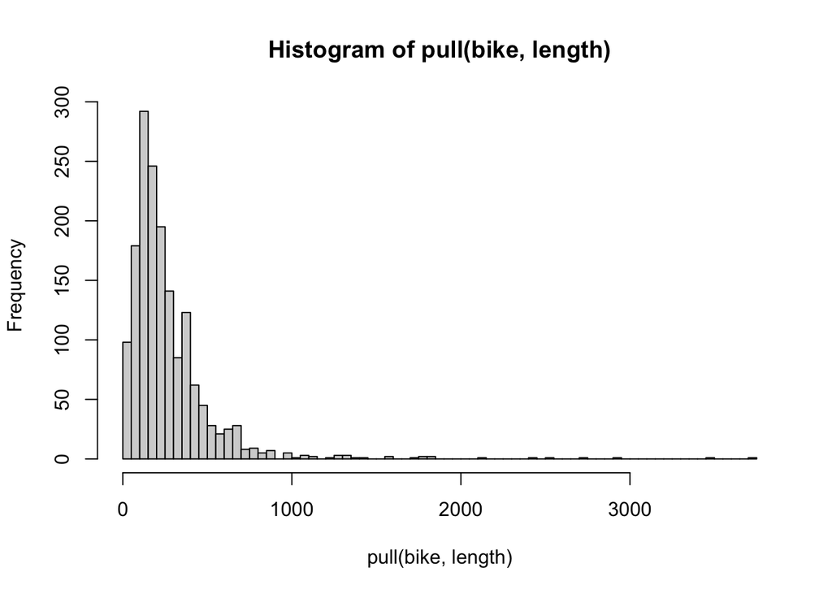

```r
hist( pull(bike, length), breaks = 100)
```

10. Create a scatterplot with `dateInstalled` on the x axis and `length` on the y axis.

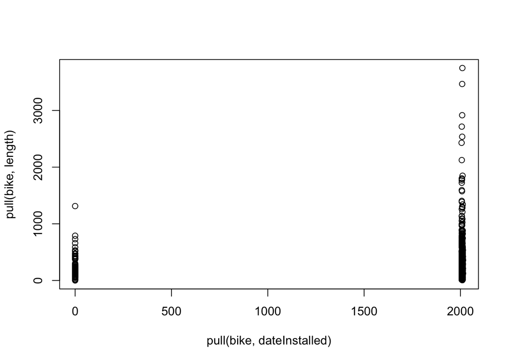

```r
plot( pull(bike, dateInstalled), pull(bike, length) )
```

**Bonus**

A. Summarize the `bike` data to get the mean of `length` and `dateInstalled`. Do this three ways: 1) with `summarize`, 2) with `summarize` and `across`, and 3) with `colMeans()`.

```r
bike %>% summarize( mean_length = mean(length, na.rm = TRUE),
                    mean_date = mean(dateInstalled, na.rm = TRUE))
```

```
## # A tibble: 1 x 2
##   mean_length mean_date
##         <dbl>     <dbl>
## 1        269.     1854.
```

```r
bike %>%
  summarize(across( c(length, dateInstalled), ~ mean(.x, na.rm = TRUE)))
```

```
## # A tibble: 1 x 2
##   length dateInstalled
##    <dbl>         <dbl>
## 1   269.         1854.
```

```r
bike %>% select(length, dateInstalled) %>% colMeans()
```

```
##        length dateInstalled
##      269.4344     1853.9454
```

You should have gotten a mean date sometime in the 1800s - that doesn’t make much sense! Hypothesize why the average date is a date from before bike lanes were being built in Baltimore.

> There are probably some zeros or other incorrect low values in the data.

B. Change any zeros in `bike$dateInstalled` to `NA` using `mutate`. For the curious,`ifelse()` in R works takes the same arguments as the “IF” function in Excel!

```r
bike <- bike %>%
  mutate(dateInstalled = ifelse(dateInstalled == 0, NA, dateInstalled))

bike$dateInstalled[bike$dateInstalled == "0"] <- NA

# How to find NAs?
# is.na(bike$dateInstalled)
# !is.na(bike$dateInstalled)
```

What is another way to remove zeros from the data?

> Add a filtering step

C. What was the average bike lane length grouped by `dateInstalled`? Remove `NA`s with `na.rm = TRUE`.

```r
bike %>%
  group_by(dateInstalled) %>%
  summarise(mean_of_the_bike = mean(length, na.rm = F))
```

```
## # A tibble: 9 x 2
##   dateInstalled mean_of_the_bike
##           <dbl>            <dbl>
## 1          2006            1469.
## 2          2007             310.
## 3          2008             249.
## 4          2009             407.
## 5          2010             246.
## 6          2011             233.
## 7          2012             271.
## 8          2013             290.
## 9            NA             215.
```

```r
# Can combine 6 & 7!
mean(bike$length[ !is.na(bike$dateInstalled)])
```

```
## [1] 273.9943
```

```r
bike %>%
  mutate(length = ifelse(length == 0, NA, length)) %>%
  group_by(dateInstalled) %>%
  summarise(n = n(), # Add this column if you want!
            mean_of_the_bike = mean(length, na.rm = TRUE),
            n_missing = sum(is.na(length))) # Add this column if you want!
```

```
## # A tibble: 9 x 4
##   dateInstalled     n mean_of_the_bike n_missing
##           <dbl> <int>            <dbl>     <int>
## 1          2006     2            1469.         0
## 2          2007   368             310.         0
## 3          2008   206             249.         0
## 4          2009    86             407.         0
## 5          2010   625             246.         0
## 6          2011   101             233.         0
## 7          2012   107             271.         0
## 8          2013    10             290.         0
## 9            NA   126             217.         1
```

D. Does the plot from question 10 improve if you remove the zeros?

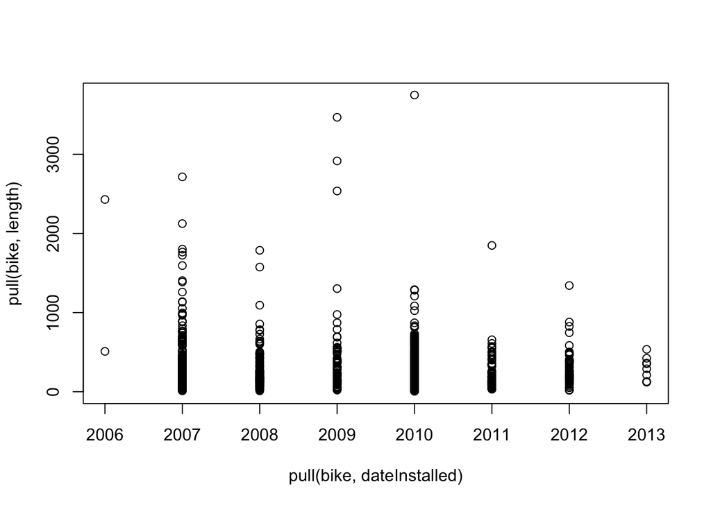

```r
plot( pull(bike, dateInstalled), pull(bike, length) )
```

> Yes!

E. What kind of plot would be better for showing the length by each year group? Make this plot.

> A boxplot would be more appropriate since year behaves more as a category than a continuous number.

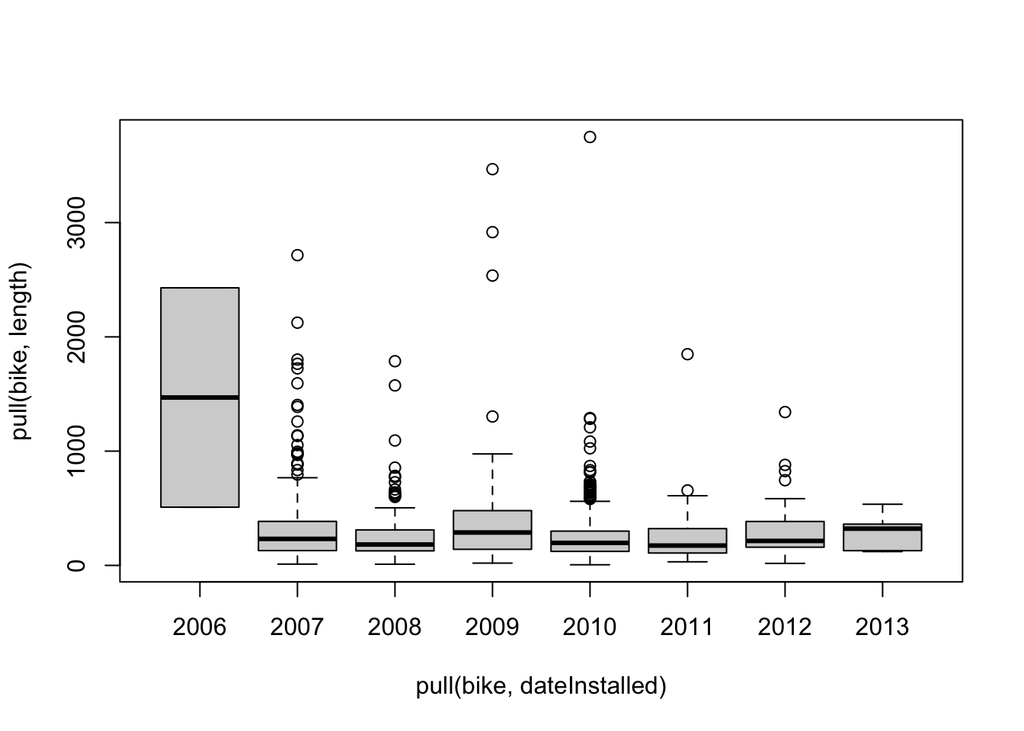

```r
boxplot( pull(bike, length) ~ pull(bike, dateInstalled) )
```